# Time Tracking Project

## Goals:

1. To understand the number of “productive hours” in a week. Productive is defined as hours logged to a particular project and not just to CIDA, BIOS, or the University. You and I will have to work to define productive well. And the distribution of productive hours across team members and by position type.
2. To understand the total number of hours logged in a week and the distribution of total number of hours logged and distribution by position type.
3. To understand the amount of time/hours being spent on email and on service.
4. To understand the number of projects worked on each week.
5. To understand the total number of hours over 6 weeks on particular projects

## Instructions

1. Extract members’ name from their email(primary) or toggl file name and create a id column(membersid.xlsx).
2. Merge table1 with personal table in ./DataRaw for getting position of each person(table2).
3. Format and concatenate each table2 to one table(members timetrack.xlsx) in ./DataProcessed.

## Empty values

| column | # NA | Duration(hours) of NA |
| --- | --- | --- |
| Project | 1014 | 914.3628 |
| Tags | 562 | 794.6423 |

## Distributions

### Number of hours logged each week

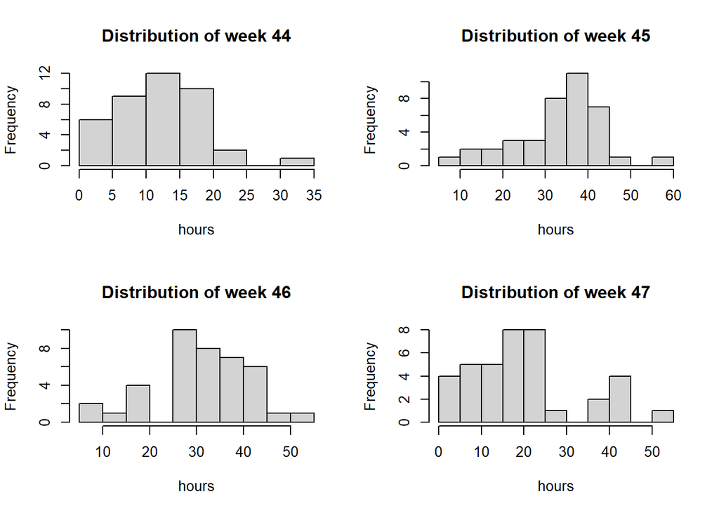

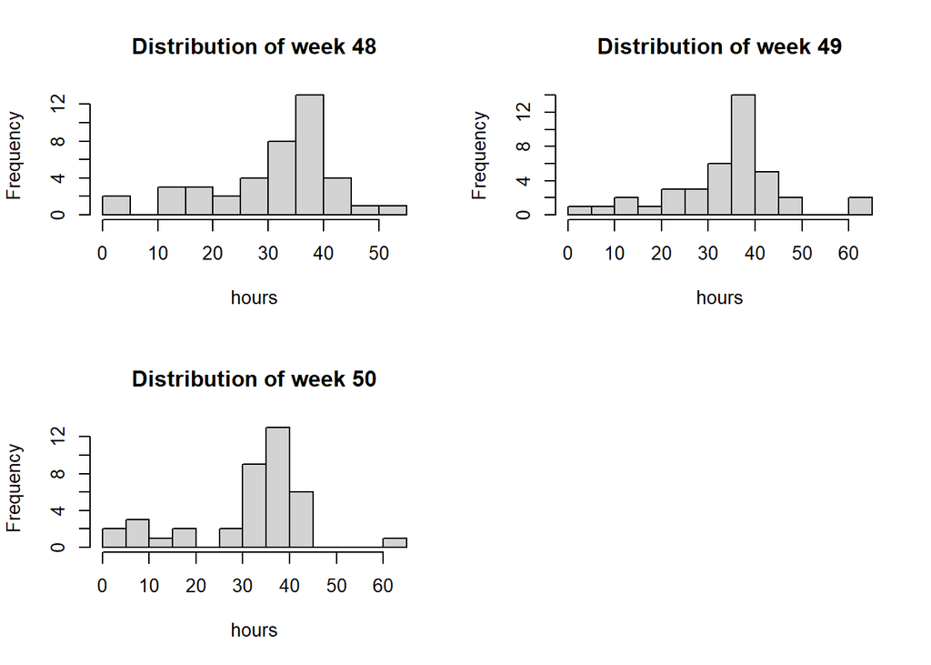

### Number of hours email each week

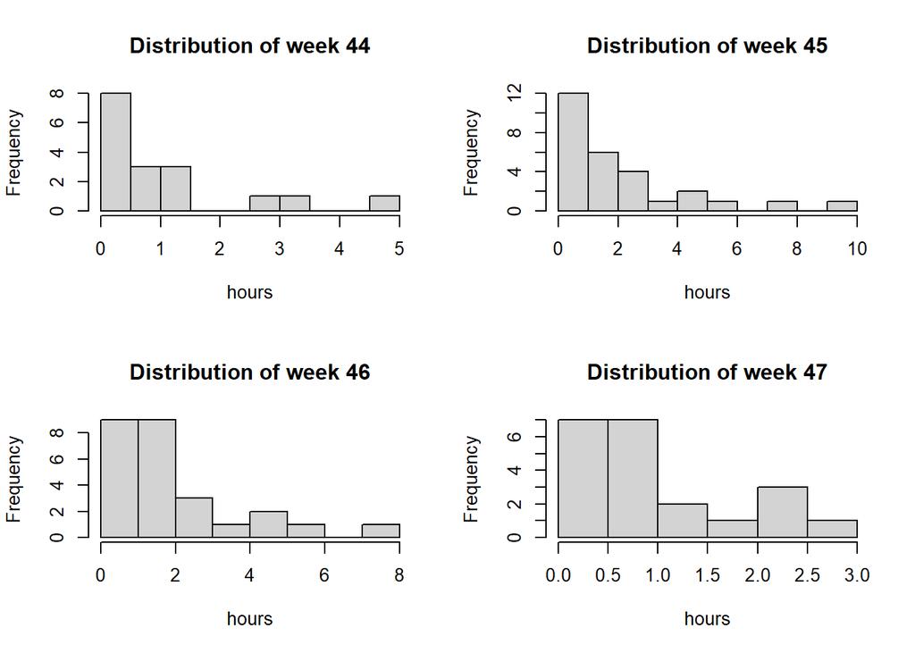

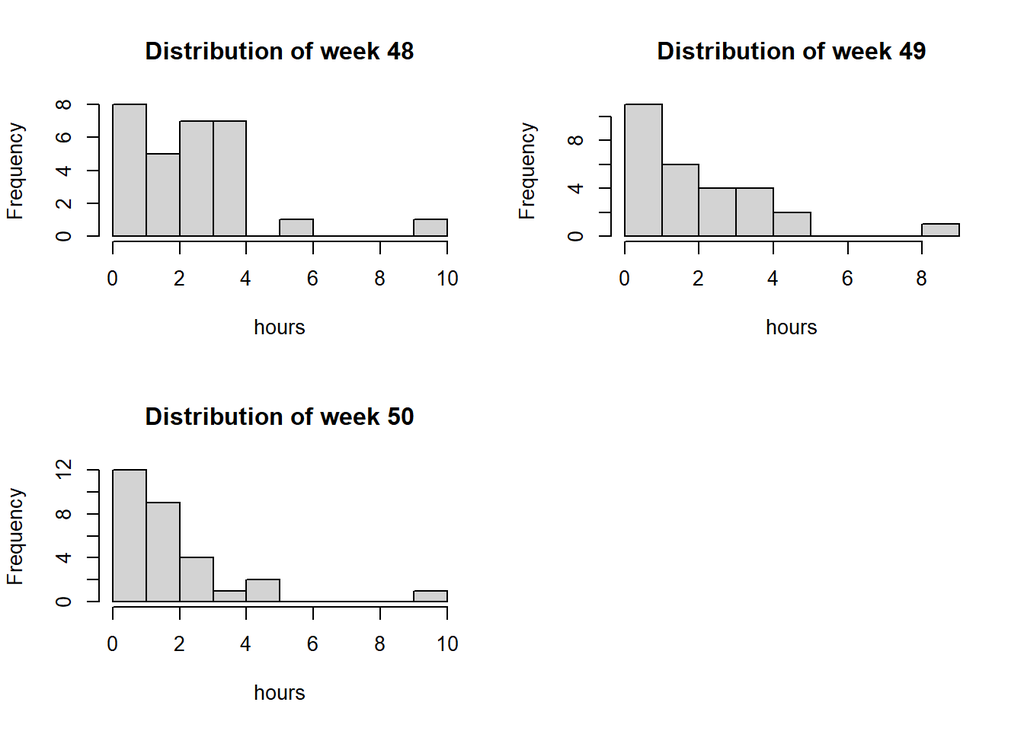

### Number of hours service each week

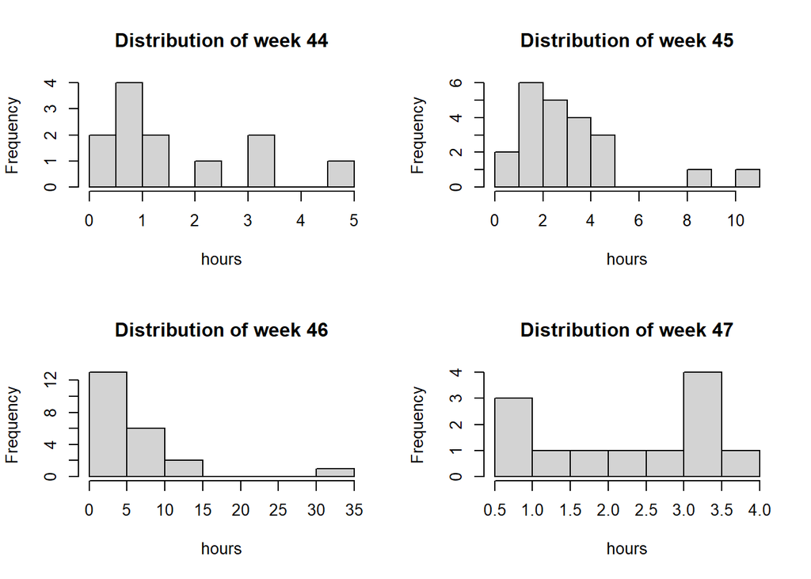

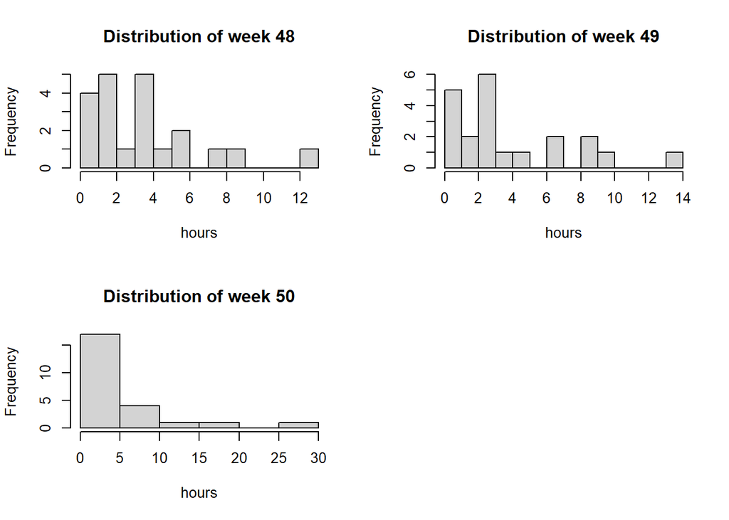

### Tags

Primary tags

| Week | Primary.tags | Duration(hours) | rate |
| --- | --- | --- | --- |
| 44 | Analysis/Coding | 94.42 | 0.2275619 |
| 44 | Meeting | 53.12 | 0.1280247 |
| 44 | Admin | 45.13 | 0.1087680 |
| 44 | Data Management | 25.98 | 0.0626145 |
| 44 | Email | 23.87 | 0.0575292 |
| 44 | Long Meeting | 23.05 | 0.0555529 |
| 44 | Report Writing And Reviewing | 15.15 | 0.0365131 |
| 44 | Literature Review/Background Work | 13.55 | 0.0326569 |
| 44 | Teaching | 11.88 | 0.0286320 |
| 44 | Grant Writing | 9.78 | 0.0235708 |

| Week | Primary.tags | Duration(hours) | rate |
| --- | --- | --- | --- |
| 45 | Analysis/Coding | 242.41 | 0.2128607 |
| 45 | Meeting | 112.33 | 0.0986372 |
| 45 | Email | 89.19 | 0.0783179 |
| 45 | Long Meeting | 63.40 | 0.0556717 |
| 45 | Teaching | 60.73 | 0.0533271 |
| 45 | Admin | 54.29 | 0.0476722 |
| 45 | Paper Revisions | 50.74 | 0.0445549 |
| 45 | Data Management | 42.72 | 0.0375125 |
| 45 | Literature Review/Background Work | 37.39 | 0.0328322 |
| 45 | Grant Writing | 30.00 | 0.0263431 |

| Week | Primary.tags | Duration(hours) | rate |
| --- | --- | --- | --- |
| 46 | Analysis/Coding | 230.68 | 0.2066062 |
| 46 | Meeting | 101.59 | 0.0909881 |
| 46 | Email | 93.51 | 0.0837513 |
| 46 | Long Meeting | 87.87 | 0.0786999 |
| 46 | Teaching | 69.42 | 0.0621753 |
| 46 | Data Management | 68.18 | 0.0610647 |
| 46 | Service - External | 59.37 | 0.0531741 |
| 46 | Admin | 40.89 | 0.0366227 |
| 46 | Report Writing And Reviewing | 37.77 | 0.0338283 |
| 46 | Literature Review/Background Work | 33.48 | 0.0299860 |

| Week | Primary.tags | Duration(hours) | rate |
| --- | --- | --- | --- |
| 47 | Analysis/Coding | 136.02 | 0.2614512 |
| 47 | Email | 43.19 | 0.0830178 |
| 47 | Data Management | 37.17 | 0.0714464 |
| 47 | Meeting | 34.78 | 0.0668525 |
| 47 | Long Meeting | 32.42 | 0.0623162 |
| 47 | Literature Review/Background Work | 31.28 | 0.0601249 |
| 47 | Pto_sick | 24.00 | 0.0461317 |
| 47 | Report Writing And Reviewing | 22.14 | 0.0425565 |
| 47 | Teaching | 21.92 | 0.0421336 |
| 47 | Paper Revisions | 18.76 | 0.0360596 |

| Week | Primary.tags | Duration(hours) | rate |
| --- | --- | --- | --- |
| 48 | Analysis/Coding | 299.61 | 0.2586703 |
| 48 | Email | 112.49 | 0.0971190 |
| 48 | Meeting | 102.37 | 0.0883818 |
| 48 | Long Meeting | 79.42 | 0.0685678 |
| 48 | Data Management | 68.84 | 0.0594335 |
| 48 | Teaching | 64.42 | 0.0556174 |
| 48 | Report Writing And Reviewing | 48.96 | 0.0422699 |
| 48 | Admin | 43.89 | 0.0378927 |
| 48 | Paper Revisions | 39.21 | 0.0338522 |
| 48 | Literature Review/Background Work | 38.04 | 0.0328421 |

| Week | Primary.tags | Duration(hours) | rate |
| --- | --- | --- | --- |
| 49 | Analysis/Coding | 254.52 | 0.2133034 |
| 49 | Meeting | 133.77 | 0.1121075 |
| 49 | Long Meeting | 103.69 | 0.0868986 |
| 49 | Email | 79.52 | 0.0666426 |
| 49 | Data Management | 73.51 | 0.0616059 |
| 49 | Admin | 56.92 | 0.0477025 |
| 49 | Literature Review/Background Work | 45.34 | 0.0379977 |
| 49 | Teaching | 43.93 | 0.0368160 |
| 49 | Paper Revisions | 40.91 | 0.0342851 |
| 49 | Report Writing And Reviewing | 39.89 | 0.0334303 |

| Week | Primary.tags | Duration(hours) | rate |
| --- | --- | --- | --- |
| 50 | Analysis/Coding | 258.16 | 0.2306627 |
| 50 | Meeting | 114.33 | 0.1021524 |
| 50 | Long Meeting | 91.29 | 0.0815665 |
| 50 | Email | 88.16 | 0.0787698 |
| 50 | Data Management | 80.38 | 0.0718185 |
| 50 | Admin | 42.61 | 0.0380715 |
| 50 | Teaching | 38.86 | 0.0347209 |
| 50 | Report Writing And Reviewing | 31.96 | 0.0285559 |
| 50 | Service - External | 29.55 | 0.0264026 |
| 50 | Literature Review/Background Work | 28.98 | 0.0258933 |

### teaching

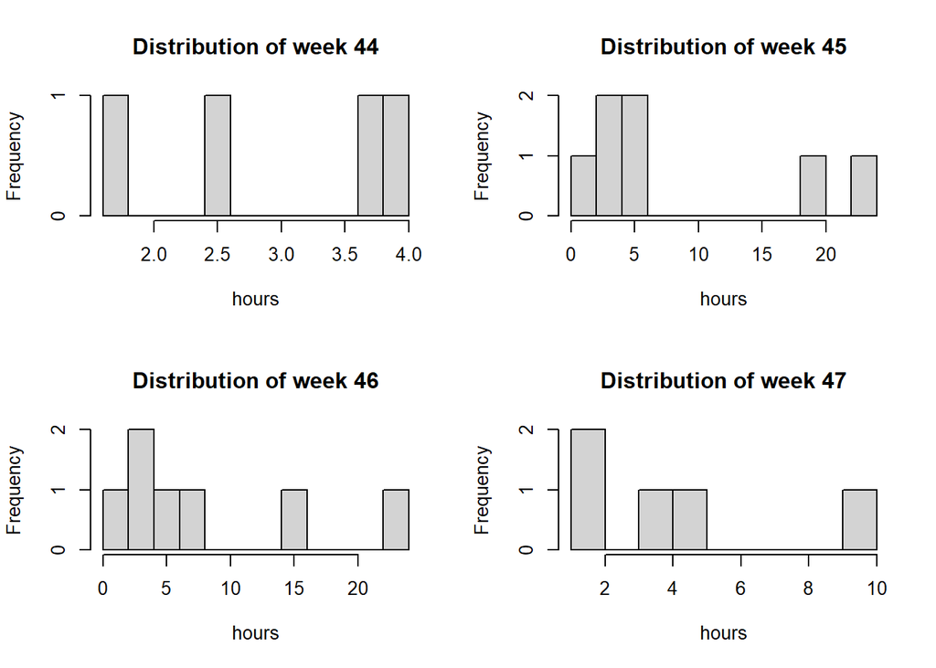

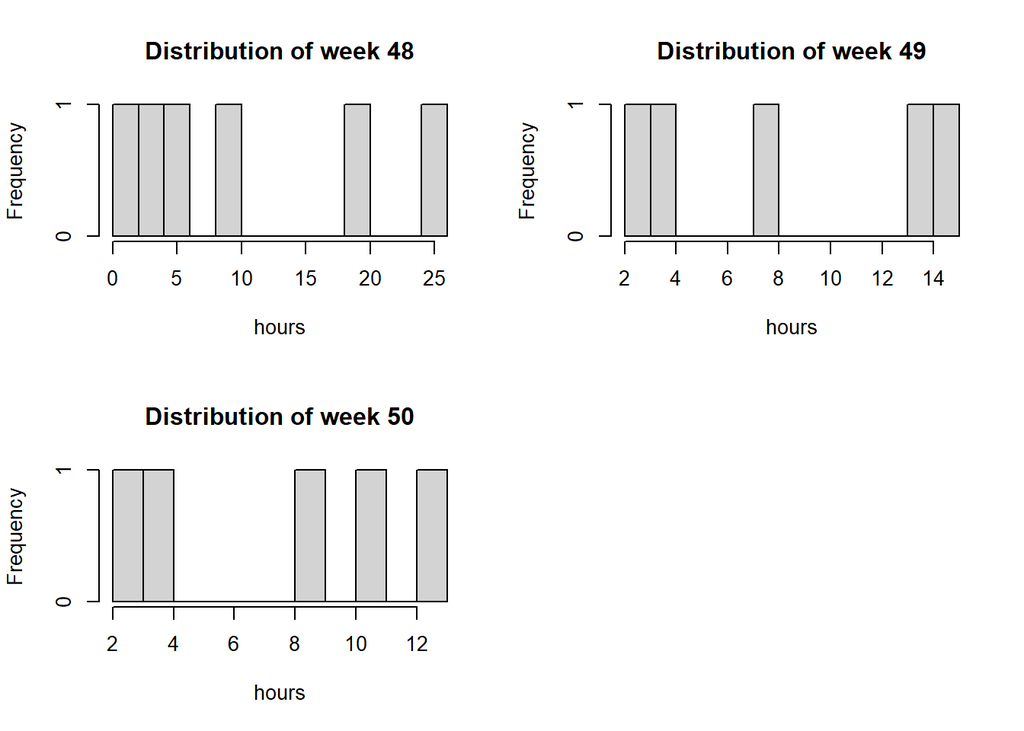

```r
par(mfrow=c(2,2))
for(i in c(44:50)){
  plot_dist(df_teaching,i)
}
```